# Forecasting future movement from speed trajectories in Roe Deer using a linear predictive model and time series analysis

## Preprocessing

The pre-processing stage can be split up into two parts, the data artifacts handling part and the data preparation part. We will start with some general data preparation parts which include a definition of the area of interest and some simple processing code chunks so that the deer data is easier to use in further analyses.This included changing values so that they were numeric, as well as renaming variables and features for consistent and clear further processing. In addition, the coordinates had to be reprojected, as the coordinates in the data set of the 15 roe deer were in the old country triangulation LV03 and thus had to be converted to the new country triangulation LV95 first. In addition, the data were reaggregated into simple features, which greatly simplified spatial analysis. A bounding box of the study area was created and enlarged by one kilometer on each side to further down the line extract the data of the Arealstatistik. The reason to why it was enlarged was that we might need the data of the Arealstatistik, which lies outside of the furthest data point, as their future movement prediction might end up there.

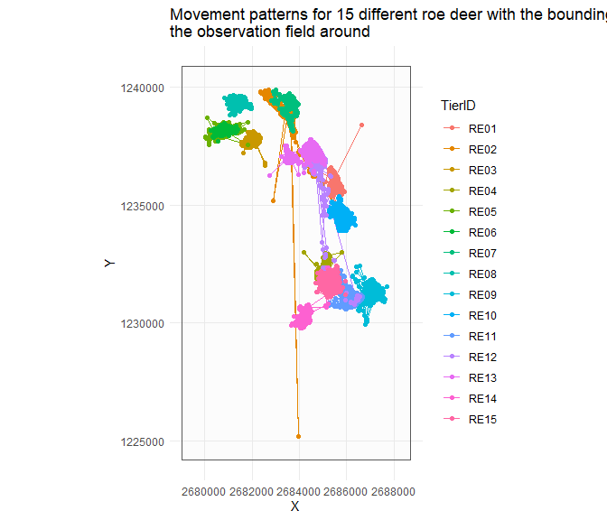

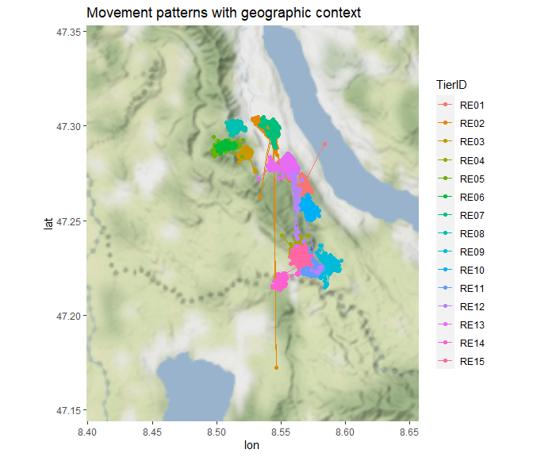

## Geometry calculations

On first visual inspection the data, most of the coordinate points seem to make sense spatially, as usual with some exceptions. Some of the point are suspiciously far apart from the others, which led us to believe that they might be outliers caused by problems of the measurements or artifacts of data handling somewhere along the way. Adding geographic context reinforce these suspicions, as for example one of data points of the deer labeled “RE01” lies in the lake of Zurich, which is rather implausible. Detecting spatial outliers might be easy from a visualization and from spatial context but is not as easy to compute. After thinking about and trying different solutions considering nearest distances, speed metrics we ended up removing outliers derived from strongly deviating steplenghts. In order to calculate those our first geometry calculations had to be computed, namely steplengths and speeds derived from the coordinate points and the time stamps.

## Outlier Handling

For the outlier removal we chose the attribute steplength. On inspection of the speed variable, which we initially deemed most appropriate for spotting outliers, we realized that basically all speeds were very low in velocity and even the highest speeds were plausible speeds for deer movement. These low speeds can be explained with the temporal sampling intervals as the deer tend to stay in a small area and might end up at the same starting and endpoint between records of the coordinate and time. This effects is reinforced with long sampling intervals because the speed is a function of the timelag and behaves accordingly if the probability increases over time that a deer moves backwards or sideways instead of in only one direction. Therefore, although the value of the steplength is also problematic with certain samplings, it is still more useful for detecting outliers as a long movement in one direction is very rare, no matter the timelag. To remove the outliers we filtered the first and the last percentile of the points per deer.

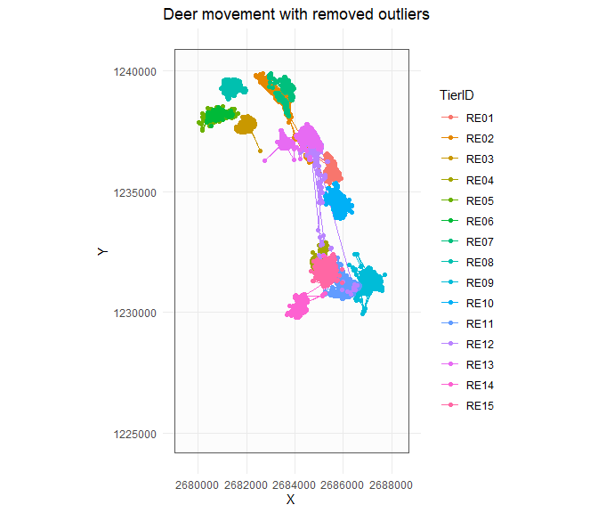

After the removal of the outliers the timelags, steplengths and speeds had to be recalculated and we additionally used the package moveHMM (Michelot et al., 2016) to calculate the turning angles of each data point for further use.

The following three plots visualize the nature and the potentially problematic aspects of the additional deer variables, namely:  
- Speed: Very clustered low values with some very high values, but not absolutely high (max. ~3 m/s) but just relatively  
- Steplength: Similar to the speeds, clustered low values with some high values.  
- Sampling intervals: Most samplings between 10’000 and 20’000 seconds (3 - 6h), some lower (5min), some higher (result of removing outliers and recalculating new timelags)

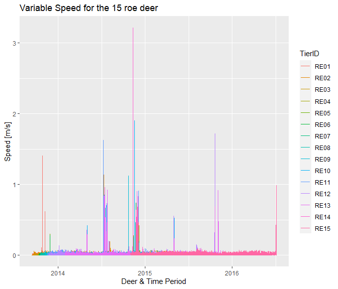

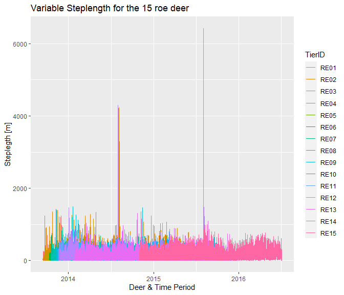

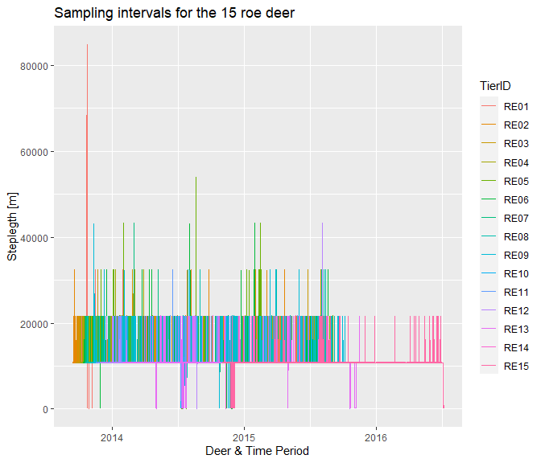